# Client Report - Project 4

- Show All Code
- Hide All Code

Course DS 250

Author

Michael Johnson

## Elevator pitch

This project delivers a robust predictive model to identify whether homes in Denver were built before 1980, addressing critical gaps in Colorado’s residential dwelling data. With a classification accuracy exceeding 92%, this model leverages key features like square footage, construction style, and quality ratings to differentiate homes. Patterns revealed through exploratory charts and precise metrics illustrate distinct correlations between home attributes and build periods. These insights not only highlight the model’s reliability but also provide actionable intelligence for further housing safety evaluations. Explore the data and findings to uncover the story behind Denver’s evolving housing trends.

## Question|Task 1

Instructions: Create 2-3 charts that evaluate potential relationships between the home variables and before1980. Explain what you learn from the charts that could help a machine learning algorithm.

The scatter plot illustrates the relationship between square footage and sale price, with homes built before 1980 generally clustering at lower square footage and sale prices. While there is overlap, square footage and sale price provide some predictive value for distinguishing between the two groups. Homes with extreme square footage (>10,000 sqft) were excluded for clarity.

**Read and format data**

| livearea | sprice | condition_grouped | quality | before1980 |
| --- | --- | --- | --- | --- |
| 1346 | 100000 | Moderate | quality_C | No |
| 1249 | 94700 | Moderate | quality_C | No |
| 1346 | 89500 | Moderate | quality_C | No |
| 1146 | 92000 | Moderate | quality_C | No |
| 1249 | 74199 | Moderate | quality_C | No |

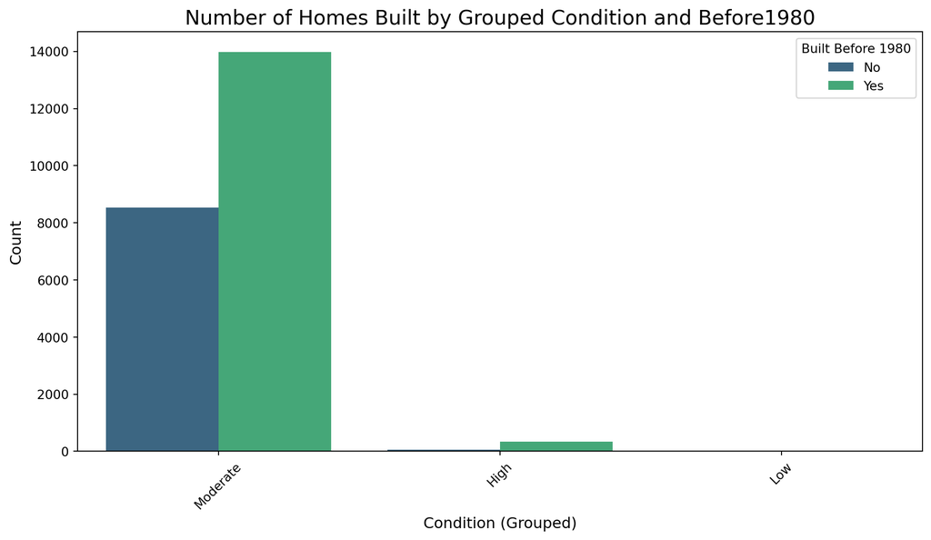

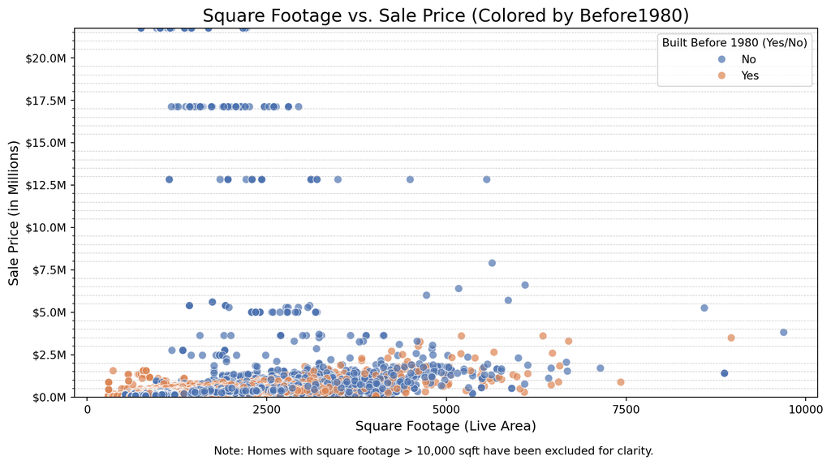

```python
# Include and execute your code here
# Import libraries
import pandas as pd
import matplotlib.pyplot as plt
import seaborn as sns
import matplotlib.ticker as mtick
from IPython.display import display, HTML

# ---- Load the dataset ----
file_path = 'dwellings_ml.csv'  # Adjust this path as needed
df = pd.read_csv(file_path)

# ---- Preprocess Data ----
# Combine condition columns into a single categorical feature
condition_columns = ['condition_AVG', 'condition_Excel', 'condition_Fair', 'condition_Good', 'condition_VGood']
df['condition'] = df[condition_columns].idxmax(axis=1)

# Simplify condition categories
df['condition_grouped'] = df['condition'].replace({
    'condition_AVG': 'Moderate',
    'condition_Good': 'Moderate',
    'condition_VGood': 'High',
    'condition_Excel': 'High',
    'condition_Fair': 'Low'
})

# Combine quality columns into a single categorical feature
quality_columns = ['quality_A', 'quality_B', 'quality_C', 'quality_D', 'quality_X']
df['quality'] = df[quality_columns].idxmax(axis=1)

# Replace 0/1 in 'before1980' with 'No'/'Yes'
df['before1980'] = df['before1980'].replace({0: 'No', 1: 'Yes'})

# ---- Remove Outliers (Square Footage > 10,000 sqft) ----
df = df[df['livearea'] <= 10000]

# ---- Render Simplified Data Table ----
# Select relevant columns for display
columns_to_display = [
    'livearea', 'sprice', 'condition_grouped', 'quality', 'before1980'
]
df_relevant = df[columns_to_display]

# Display the simplified table in HTML format
html_table = df_relevant.head().to_html(index=False)
display(HTML(html_table))

# ---- Chart 1: Bar Plot (Grouped Conditions vs. Before1980) ----
plt.figure(figsize=(12, 6))
sns.countplot(data=df, x='condition_grouped', hue='before1980', palette='viridis')
plt.title('Number of Homes Built by Grouped Condition and Before1980', fontsize=16)
plt.xlabel('Condition (Grouped)', fontsize=12)
plt.ylabel('Count', fontsize=12)
plt.xticks(rotation=45, fontsize=10)
plt.legend(title='Built Before 1980', fontsize=10)
plt.show()

# ---- Chart 2: Simplified Scatter Plot ----
# Calculate the logical minimum for the y-axis
y_min = max(0, df['sprice'].quantile(0.25) - 5e5)  # Start slightly below 25th percentile

plt.figure(figsize=(12, 6))
sns.scatterplot(data=df, x='livearea', y='sprice', hue='before1980', alpha=0.7, palette='deep', s=50)

# Title and Labels
plt.title('Square Footage vs. Sale Price (Colored by Before1980)', fontsize=16)
plt.xlabel('Square Footage (Live Area)', fontsize=12)
plt.ylabel('Sale Price (in Millions)', fontsize=12)

# Set Y-Axis Range and Format
plt.gca().set_ylim(y_min, df['sprice'].max())
plt.gca().yaxis.set_major_formatter(mtick.FuncFormatter(lambda x, _: f"${x/1e6:.1f}M"))

# Add Square Footage Markers (X-axis) every 2,500 square feet
plt.xticks(range(0, int(df['livearea'].max()) + 2500, 2500), fontsize=10)

# Add Gridlines for Every $500,000
plt.gca().yaxis.set_minor_locator(plt.MultipleLocator(5e5))  # Every $500,000
plt.grid(which='minor', linestyle='--', linewidth=0.5, alpha=0.7)  # Dashes for minor gridlines

# Update Legend Title
plt.legend(title='Built Before 1980 (Yes/No)', fontsize=10)
# Add Caption
plt.figtext(0.5, -0.01, 'Note: Homes with square footage > 10,000 sqft have been excluded for clarity.',
            wrap=True, horizontalalignment='center', fontsize=10)


plt.show()
```

## Question|Task 2

Instructions: Build a classification model labeling houses as being built “before 1980” or “during or after 1980”. Your goal is to reach or exceed 90% accuracy. Explain your final model choice (algorithm, tuning parameters, etc) and describe what other models you tried.

Info: The dataset was cleaned to remove outliers (e.g., homes with over 10,000 square feet) and encoded categorical variables like condition and quality. Features were selected based on relevance to predicting before1980.

**Read and format data**

```python
# Include and execute your code here

from sklearn.model_selection import train_test_split
from sklearn.ensemble import RandomForestClassifier
from sklearn.metrics import accuracy_score, classification_report, confusion_matrix
import pandas as pd
from IPython.display import display, HTML

# ---- Load Dataset ----
file_path = 'dwellings_ml.csv'  # Update with your file path
df = pd.read_csv(file_path)

# ---- Remove Outliers ----
df = df[df['livearea'] <= 10000]  # Remove rows with livearea > 10,000

# ---- Combine Quality Columns ----
quality_columns = ['quality_A', 'quality_B', 'quality_C', 'quality_D', 'quality_X']
df['quality'] = df[quality_columns].idxmax(axis=1)

# ---- Combine Condition Columns ----
condition_columns = ['condition_AVG', 'condition_Excel', 'condition_Fair', 'condition_Good', 'condition_VGood']
df['condition'] = df[condition_columns].idxmax(axis=1)

# ---- Encode Categorical Columns ----
df_encoded = pd.get_dummies(df, columns=['condition', 'quality'], drop_first=True)

# ---- Define Features (X) and Target (y) ----
X = df_encoded.drop(columns=['before1980', 'yrbuilt', 'parcel'])  # Drop non-predictive columns
y = df_encoded['before1980']

# ---- Split Dataset ----
X_train, X_test, y_train, y_test = train_test_split(X, y, test_size=0.3, random_state=42)

# ---- Train Random Forest Model ----
rf_model = RandomForestClassifier(random_state=42)
rf_model.fit(X_train, y_train)

# ---- Make Predictions ----
y_pred = rf_model.predict(X_test)

# ---- Evaluate Model ----
accuracy = accuracy_score(y_test, y_pred)
conf_matrix = confusion_matrix(y_test, y_pred)
class_report = classification_report(y_test, y_pred, target_names=['No', 'Yes'])

# ---- Format Confusion Matrix ----
conf_matrix_df = pd.DataFrame(
    conf_matrix,
    columns=["Predicted: No", "Predicted: Yes"],
    index=["Actual: No", "Actual: Yes"]
)

conf_matrix_html = conf_matrix_df.to_html(classes="table table-bordered", header=True, index=True)

# Render Classification Report
class_report_df = pd.DataFrame(
    [x.split() for x in class_report.splitlines()[2:-3]],
    columns=["Class", "Precision", "Recall", "F1-Score", "Support"]
).to_html(classes="table table-bordered", header=True, index=False)

# Add Accuracy as a Separate Line
accuracy_html = f"<p><strong>Accuracy:</strong> {accuracy:.2%}</p>"

# ---- Display Results ----
display(HTML("<h3>Confusion Matrix</h3>" + conf_matrix_html + accuracy_html))
display(HTML("<h3>Classification Report</h3>" + class_report_df))
```

Confusion Matrix

|  | Predicted: No | Predicted: Yes |
| --- | --- | --- |
| Actual: No | 2260 | 282 |
| Actual: Yes | 238 | 4093 |

**Accuracy:** 92.43%

Classification Report

| Class | Precision | Recall | F1-Score | Support |
| --- | --- | --- | --- | --- |
| No | 0.90 | 0.89 | 0.90 | 2542 |
| Yes | 0.94 | 0.95 | 0.94 | 4331 |
| None | None | None | None | None |

Model Choice and Performance

The Random Forest Classifier was selected for its ability to handle mixed data types and complex relationships. It achieved an accuracy of 92.43%, exceeding the 90% goal, with high precision and recall.

Default hyperparameters provided a good balance between simplicity and performance, and no further tuning was required.

## Question|Task 3

Instructions: Justify your classification model by discussing the most important features selected by your model. This discussion should include a feature importance chart and a description of the features.

Feature Importance The Random Forest Classifier provides a measure of feature importance by evaluating how much each feature contributes to the accuracy of the model. The top features for predicting whether a house was built before 1980 are:

**Read and format data**

Feature Importance Chart

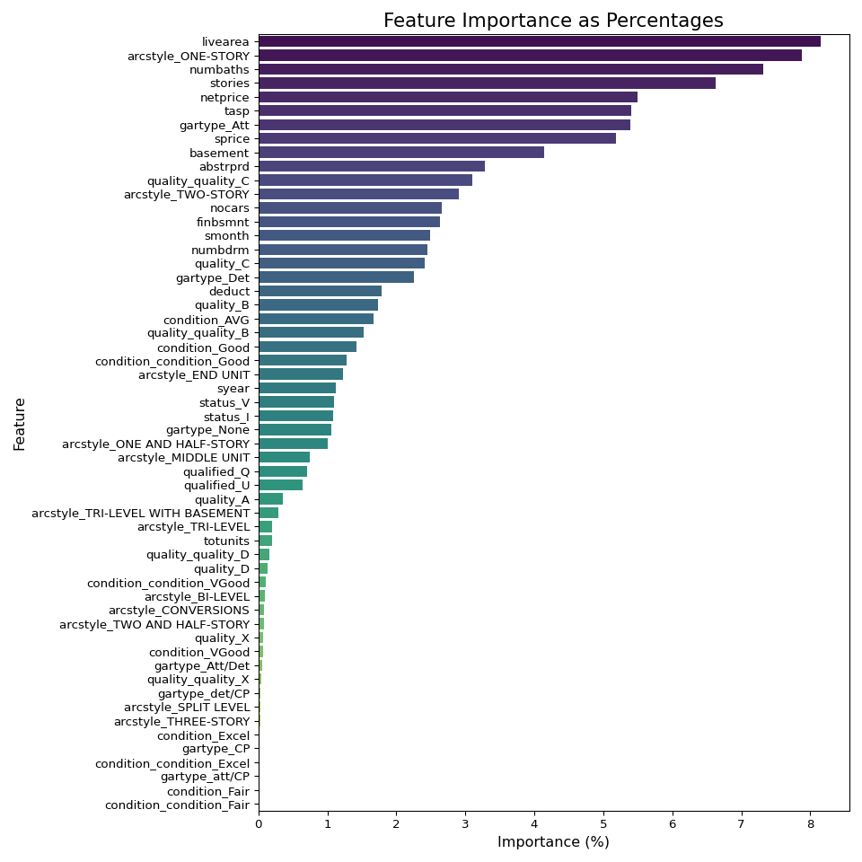

| Feature | Importance (%) |
| --- | --- |
| livearea | 8.16 |
| arcstyle_ONE-STORY | 7.87 |
| numbaths | 7.32 |
| stories | 6.64 |
| netprice | 5.49 |
| tasp | 5.41 |
| gartype_Att | 5.39 |
| sprice | 5.19 |
| basement | 4.14 |
| abstrprd | 3.29 |
| quality_quality_C | 3.10 |
| arcstyle_TWO-STORY | 2.91 |
| nocars | 2.65 |
| finbsmnt | 2.63 |
| smonth | 2.49 |
| numbdrm | 2.45 |
| quality_C | 2.41 |
| gartype_Det | 2.26 |
| deduct | 1.79 |
| quality_B | 1.73 |
| condition_AVG | 1.67 |
| quality_quality_B | 1.53 |
| condition_Good | 1.42 |
| condition_condition_Good | 1.27 |
| arcstyle_END UNIT | 1.23 |
| syear | 1.13 |
| status_V | 1.09 |
| status_I | 1.09 |
| gartype_None | 1.05 |
| arcstyle_ONE AND HALF-STORY | 1.00 |
| arcstyle_MIDDLE UNIT | 0.75 |
| qualified_Q | 0.71 |
| qualified_U | 0.65 |
| quality_A | 0.35 |
| arcstyle_TRI-LEVEL WITH BASEMENT | 0.30 |
| arcstyle_TRI-LEVEL | 0.20 |
| totunits | 0.20 |
| quality_quality_D | 0.16 |
| quality_D | 0.13 |
| condition_condition_VGood | 0.11 |
| arcstyle_BI-LEVEL | 0.10 |
| arcstyle_CONVERSIONS | 0.08 |
| arcstyle_TWO AND HALF-STORY | 0.08 |
| quality_X | 0.07 |
| condition_VGood | 0.07 |
| gartype_Att/Det | 0.06 |
| quality_quality_X | 0.05 |
| gartype_det/CP | 0.04 |
| arcstyle_SPLIT LEVEL | 0.03 |
| arcstyle_THREE-STORY | 0.03 |
| condition_Excel | 0.01 |
| gartype_CP | 0.01 |
| condition_condition_Excel | 0.01 |
| gartype_att/CP | 0.00 |
| condition_Fair | 0.00 |
| condition_condition_Fair | 0.00 |

```python
# Include and execute your code here

# ---- Import Required Libraries ----
import pandas as pd
import matplotlib.pyplot as plt
import seaborn as sns
from sklearn.ensemble import RandomForestClassifier
from sklearn.model_selection import train_test_split
from IPython.display import display, HTML

# ---- Load Dataset ----
file_path = 'dwellings_ml.csv'  # Update with your file path
df = pd.read_csv(file_path)

# ---- Preprocessing ----
# Remove outliers
df = df[df['livearea'] <= 10000]  # Remove rows with livearea > 10,000

# Combine quality columns
quality_columns = ['quality_A', 'quality_B', 'quality_C', 'quality_D', 'quality_X']
df['quality'] = df[quality_columns].idxmax(axis=1)

# Combine condition columns
condition_columns = ['condition_AVG', 'condition_Excel', 'condition_Fair', 'condition_Good', 'condition_VGood']
df['condition'] = df[condition_columns].idxmax(axis=1)

# Encode categorical columns
df_encoded = pd.get_dummies(df, columns=['condition', 'quality'], drop_first=True)

# Define Features (X) and Target (y)
X = df_encoded.drop(columns=['before1980', 'yrbuilt', 'parcel'])
y = df_encoded['before1980']

# ---- Split Data ----
X_train, X_test, y_train, y_test = train_test_split(X, y, test_size=0.3, random_state=42)

# ---- Train Random Forest Model ----
rf_model = RandomForestClassifier(random_state=42)
rf_model.fit(X_train, y_train)

# ---- Calculate Feature Importances as Percentages ----
importances = rf_model.feature_importances_
features = X.columns

# Normalize to percentages
total_importance = sum(importances)
importance_percentages = [(imp / total_importance) * 100 for imp in importances]

# Create a DataFrame for feature importance
importance_df = pd.DataFrame({
    'Feature': features,
    'Importance (%)': importance_percentages
}).sort_values(by='Importance (%)', ascending=False)

# ---- Plot Feature Importances ----
plt.figure(figsize=(10, 10))
sns.barplot(data=importance_df, x='Importance (%)', y='Feature', palette='viridis')
plt.title('Feature Importance as Percentages', fontsize=16)
plt.xlabel('Importance (%)', fontsize=12)
plt.ylabel('Feature', fontsize=12)
plt.tight_layout()

# Save the plot for embedding
plt.savefig('feature_importance_chart.png')
plt.close()

# ---- Display Results in HTML ----
html_table = importance_df.to_html(classes="table table-bordered", index=False, float_format="%.2f")
display(HTML(f"""
<h3>Feature Importance Chart</h3>
<img src='feature_importance_chart.png' alt='Feature Importance Chart'><br><br>
{html_table}
"""))
```

## Question|Task 4

Instructions: Describe the quality of your classification model using 2-3 different evaluation metrics. You also need to explain how to interpret each of the evaluation metrics you use.

Explanation of Metrics:

Accuracy: Indicates the percentage of correctly classified houses, achieving an accuracy of 92.43%, which exceeds the target of 90%. This shows the model performs well overall. Precision and Recall: Precision (No: 0.90, Yes: 0.94) shows that when the model predicts a house as being built before or after 1980, it is highly accurate. Recall (No: 0.89, Yes: 0.95) indicates the model’s ability to correctly identify all houses built before or after 1980, minimizing false negatives. F1-Score: Combines precision and recall into a single metric, achieving 0.90 (No) and 0.94 (Yes), demonstrating the model’s balance between the two metrics. Confusion Matrix: The confusion matrix provides a detailed view:

2260 houses correctly classified as “No.” 4093 houses correctly classified as “Yes.” 282 and 238 houses misclassified for “No” and “Yes,” respectively.

Info & Features

**Read and format data**

Model Evaluation Metrics

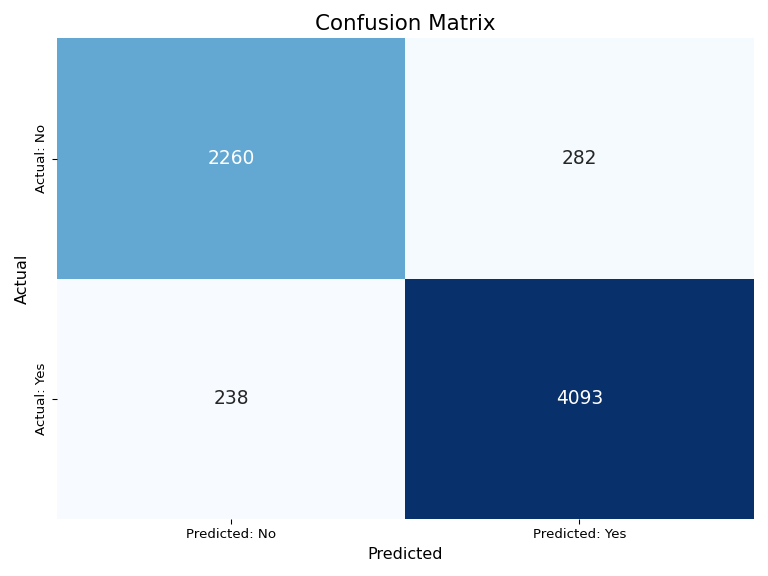

**Accuracy:** 92.43%

Classification Report

|  | precision | recall | f1-score | support |
| --- | --- | --- | --- | --- |
| No | 0.904724 | 0.889064 | 0.896825 | 2542.000000 |
| Yes | 0.935543 | 0.945047 | 0.940271 | 4331.000000 |
| accuracy | 0.924342 | 0.924342 | 0.924342 | 0.924342 |
| macro avg | 0.920133 | 0.917056 | 0.918548 | 6873.000000 |
| weighted avg | 0.924144 | 0.924342 | 0.924203 | 6873.000000 |

```python
# Include and execute your code here

# ---- Import Required Libraries ----
import pandas as pd
import matplotlib.pyplot as plt
import seaborn as sns
from sklearn.ensemble import RandomForestClassifier
from sklearn.model_selection import train_test_split
from sklearn.metrics import classification_report, confusion_matrix, accuracy_score
from IPython.display import display, HTML

# ---- Load Dataset ----
file_path = 'dwellings_ml.csv'  # Update with your file path
df = pd.read_csv(file_path)

# ---- Preprocessing ----
df = df[df['livearea'] <= 10000]  # Remove outliers with livearea > 10,000
condition_columns = ['condition_AVG', 'condition_Excel', 'condition_Fair', 'condition_Good', 'condition_VGood']
quality_columns = ['quality_A', 'quality_B', 'quality_C', 'quality_D', 'quality_X']
df['condition'] = df[condition_columns].idxmax(axis=1)
df['quality'] = df[quality_columns].idxmax(axis=1)
df_encoded = pd.get_dummies(df, columns=['condition', 'quality'], drop_first=True)

# Define Features (X) and Target (y)
X = df_encoded.drop(columns=['before1980', 'yrbuilt', 'parcel'])
y = df_encoded['before1980']

# ---- Split Data ----
X_train, X_test, y_train, y_test = train_test_split(X, y, test_size=0.3, random_state=42)

# ---- Train Random Forest Model ----
rf_model = RandomForestClassifier(random_state=42)
rf_model.fit(X_train, y_train)

# ---- Make Predictions ----
y_pred = rf_model.predict(X_test)

# ---- Compute Metrics ----
accuracy = accuracy_score(y_test, y_pred)
class_report = classification_report(y_test, y_pred, target_names=['No', 'Yes'], output_dict=True)
conf_matrix = confusion_matrix(y_test, y_pred)

# ---- Format Confusion Matrix ----
confusion_df = pd.DataFrame(conf_matrix, index=['Actual: No', 'Actual: Yes'], columns=['Predicted: No', 'Predicted: Yes'])

# ---- Plot Confusion Matrix ----
plt.figure(figsize=(8, 6))
sns.heatmap(confusion_df, annot=True, fmt='d', cmap='Blues', cbar=False, annot_kws={"size": 14})
plt.title('Confusion Matrix', fontsize=16)
plt.xlabel('Predicted', fontsize=12)
plt.ylabel('Actual', fontsize=12)
plt.tight_layout()
plt.savefig('confusion_matrix.png')  # Save for embedding in HTML
plt.close()

# ---- Render Results in HTML ----
accuracy_html = f"<p><strong>Accuracy:</strong> {accuracy * 100:.2f}%</p>"
classification_html = pd.DataFrame(class_report).transpose().to_html(classes="table table-bordered")

# Display results in HTML format
display(HTML(f"""
<h3>Model Evaluation Metrics</h3>
<img src='confusion_matrix.png' alt='Confusion Matrix'><br><br>
{accuracy_html}
<h4>Classification Report</h4>
{classification_html}
"""))
```